# Step 1: Import Libralies

```python
import pandas as pd
import numpy as np
import seaborn as sns
import matplotlib.pyplot as plt
# Shows plots in jupyter notebook

%matplotlib inline

# Set plot style
sns.set(color_codes=True)
```

# Step 2: Load Data

```python
loan_file = r'C:\Users\ZJU\Downloads\Data.xlsx'

loan_df = pd.read_excel(loan_file)
```

```python
loan_df.head()
```

|  | Unnamed: 0 | Origination Amount | 31.05.2019 | 30.06.2019 | 31.07.2019 | 31.08.2019 | 30.09.2019 | 31.10.2019 | 30.11.2019 | 31.12.2019 | ... | 31.03.2020 | 30.04.2020 | 31.05.2020 | 30.06.2020 | 31.07.2020 | 31.08.2020 | 30.09.2020 | 31.10.2020 | 30.11.2020 | 31.12.2020 |
| --- | --- | --- | --- | --- | --- | --- | --- | --- | --- | --- | --- | --- | --- | --- | --- | --- | --- | --- | --- | --- | --- |
| 0 | 31.05.2019 | 10018746.17 | 1443069.08 | 3332200.33 | 1328138.75 | 928085.74 | 736418.27 | 539403.31 | 427557.86 | 324459.32 | ... | 116684.68 | 92699.67 | 63399.66 | 53265.12 | 37121.13 | 29787.10 | 24524.90 | 18085.94 | 16581.01 | 11442.97 |
| 1 | 30.06.2019 | 10868379.04 | 0.00 | 1392751.60 | 3011884.91 | 1237868.70 | 970929.28 | 892351.83 | 668767.02 | 505612.59 | ... | 255222.42 | 198833.96 | 161996.73 | 138461.91 | 92346.68 | 79641.30 | 63457.44 | 52373.85 | 43374.70 | 37404.87 |
| 2 | 31.07.2019 | 10733932.61 | 0.00 | 0.00 | 1537650.24 | 2953335.55 | 1208316.08 | 879375.19 | 711016.84 | 658251.40 | ... | 302575.54 | 258652.52 | 191798.05 | 170027.54 | 127574.33 | 110301.21 | 89766.69 | 64746.84 | 61408.92 | 50312.70 |
| 3 | 31.08.2019 | 12558727.02 | 0.00 | 0.00 | 0.00 | 1617681.94 | 4082016.00 | 1387474.94 | 1247623.59 | 886293.35 | ... | 417223.56 | 336686.08 | 253556.20 | 200066.59 | 151859.74 | 109973.00 | 90228.14 | 70661.50 | 53102.83 | 47069.84 |
| 4 | 30.09.2019 | 14505071.44 | 0.00 | 0.00 | 0.00 | 0.00 | 1992242.84 | 3930445.60 | 1394620.78 | 1227905.58 | ... | 628429.48 | 589692.85 | 457299.31 | 323764.87 | 288152.28 | 239872.99 | 192246.98 | 171550.69 | 142575.97 | 116853.05 |

5 rows × 22 columns

# Step 3: Compute historical repayment percentages

```python
historical_repayments = loan_df.iloc[:, 1:]
origination_amounts = loan_df['Origination Amount']
repayment_percentages = historical_repayments.div(origination_amounts, axis=0)
```

```python
print(repayment_percentages)
```

```
    Origination Amount  31.05.2019  30.06.2019  31.07.2019  31.08.2019  \
0                  1.0    0.144037    0.332597    0.132565    0.092635
1                  1.0    0.000000    0.128147    0.277124    0.113896
2                  1.0    0.000000    0.000000    0.143251    0.275140
3                  1.0    0.000000    0.000000    0.000000    0.128809
4                  1.0    0.000000    0.000000    0.000000    0.000000
5                  1.0    0.000000    0.000000    0.000000    0.000000
6                  1.0    0.000000    0.000000    0.000000    0.000000
7                  1.0    0.000000    0.000000    0.000000    0.000000
8                  1.0    0.000000    0.000000    0.000000    0.000000
9                  1.0    0.000000    0.000000    0.000000    0.000000
10                 1.0    0.000000    0.000000    0.000000    0.000000
11                 1.0    0.000000    0.000000    0.000000    0.000000
12                 1.0    0.000000    0.000000    0.000000    0.000000
13                 1.0    0.000000    0.000000    0.000000    0.000000
```

[output cut: 74 more lines]

# Step 4: Compute expected repayment percentages

```python
expected_repayment_percentages = pd.Series(index=repayment_percentages.index)

expected_repayment_percentages[0] = repayment_percentages.iloc[0, 0]

expected_repayment_percentages[1] = repayment_percentages.iloc[1, 0] * 2

# Assumption for December 2020 vintage

for i in range(2, len(expected_repayment_percentages)):

    denominator = np.sum(expected_repayment_percentages[:i])

    expected_repayment_percentages[i] = expected_repayment_percentages[1] * np.log(1 + 1 - (i - 1) / 30) / (1 - denominator)
```

```python
print(expected_repayment_percentages)
```

```
0     1.000000
1     2.000000
2    -0.676340
3    -0.996095
4    -3.918943
5     0.347585
6     0.373720
7     0.409597
8     0.462589
9     0.550628
10    0.733287
11    1.430939
12   -1.368608
13    1.442523
14   -1.135316
15    2.482008
16   -0.379369
17   -0.435663
18   -0.544411
19   -0.864822
dtype: float64
```

```python
positive_count = (expected_repayment_percentages > 0).sum()
negative_count = (expected_repayment_percentages < 0).sum()

print("Number of positive values:", positive_count)
print("Number of negative values:", negative_count)
```

```
Number of positive values: 11
Number of negative values: 9
```

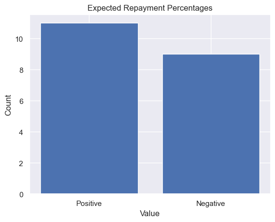

```python
import matplotlib.pyplot as plt

# Assuming you have the expected_repayment_percentages calculated as mentioned earlier

# Count positive and negative values
positive_count = (expected_repayment_percentages > 0).sum()
negative_count = (expected_repayment_percentages < 0).sum()

# Create a bar plot
plt.bar(['Positive', 'Negative'], [positive_count, negative_count])

# Customize the plot
plt.xlabel('Value')
plt.ylabel('Count')
plt.title('Expected Repayment Percentages')

# Display the plot
plt.show()
```

# Interpreting the results:

Negative values: A negative expected repayment percentage indicates that, on average, the firm expects borrowers from that vintage to repay less than the original loan amount. This suggests a less favorable repayment performance, where borrowers are expected to default or partially repay their loans, resulting in potential losses for the firm.

# Step 5: Compute forecasted cash flows

```python
forecasted_cash_flows = expected_repayment_percentages * origination_amounts
```

```python
print(forecasted_cash_flows)
```

```
0     1.001875e+07
1     2.173676e+07
2    -7.259789e+06
3    -1.250969e+07
4    -5.684455e+07
5     5.440728e+06
6     5.646059e+06
7     6.965092e+06
8     7.768894e+06
9     1.058153e+07
10    1.585960e+07
11    3.195964e+07
12   -3.064770e+07
13    3.558943e+07
14   -2.892584e+07
15    6.423143e+07
16   -9.820799e+06
17   -1.206769e+07
18   -1.626312e+07
19   -2.636236e+07
dtype: float64
```

```python
positive_count = (forecasted_cash_flows > 0).sum()
negative_count = (forecasted_cash_flows < 0).sum()

print("Positive values for forecasted_cash_flows:", positive_count)
print("Negative values for forecasted_cash_flows:", negative_count)
```

```
Positive values for forecasted_cash_flows: 11
Negative values for forecasted_cash_flows: 9
```

The forecasted cash flows represent the projected future cash inflows or outflows for the business firm. Each value in the Series corresponds to the forecasted cash flow for a given Vintage specific period or time.

Positive values: The 11 positive forecasted cash flows indicate periods where the firm expects to receive cash inflows or generate positive revenue. This suggests that the firm is anticipating income or positive financial outcomes during those periods. Positive cash flows are generally favorable as they contribute to the firm's financial stability and can be used for various purposes such as covering expenses, reinvesting in the business, or distributing dividends to shareholders. The presence of multiple positive values indicates that the firm expects to have periods of profitability or positive financial performance.

Negative values: The 9 negative forecasted cash flows represent periods where the firm expects to have cash outflows or incur expenses. This suggests that the firm anticipates financial obligations or costs during those periods. Negative cash flows are typically less desirable as they indicate funds leaving the firm and can impact profitability and liquidity. Negative cash flows may arise from various factors such as operating expenses, loan repayments, or investments in assets. The presence of multiple negative values indicates that the firm expects to have periods of financial obligations or expenses.

# Step 6: Compute present value of forecasted cash flows and portfolio

```python
discount_rate = 0.025  # 2.5% annual rate
monthly_discount_rate = (1 + discount_rate) ** (1/12) - 1
present_value = np.sum(forecasted_cash_flows / (1 + monthly_discount_rate) ** np.arange(1, len(forecasted_cash_flows) + 1))
```

```python
print (present_value)
```

```
15021934.804220017
```

# Step 7: Compare with client's estimate

```python
client_estimate = 84993122.67
absolute_difference = abs(present_value - client_estimate)
relative_difference = absolute_difference / client_estimate

# Print results
print("Present Value of Forecasted Cash Flows:", round(present_value, 2))
print("Absolute Difference from Client's Estimate:", round(absolute_difference, 2))
print("Relative Difference from Client's Estimate:", round(relative_difference, 2))
```

```
Present Value of Forecasted Cash Flows: 15021934.8
Absolute Difference from Client's Estimate: 69971187.87
Relative Difference from Client's Estimate: 0.82
```

Present Value of Forecasted Cash Flows: The present value of forecasted cash flows represents the current value of the future cash inflows and outflows, considering the time value of money. It indicates the net worth of these cash flows when discounted to the present time. The value of 15,021,934.8 suggests the expected cumulative value of the forecasted cash flows, considering the time value of money.

Absolute Difference from Client's Estimate: The absolute difference of 69,971,187.87 represents the numerical discrepancy between the client's estimate and the calculated present value. A large absolute difference indicates a significant variance between the client's estimate and the actual present value of the forecasted cash flows.

Relative Difference from Client's Estimate: The relative difference of 0.82 indicates the proportion of the absolute difference in relation to the client's estimate. A value of 0.82 suggests that the absolute difference is approximately 82% of the client's estimate.